# (Ford GoBike System)

## by (Adham AlQattawy)

## Investigation Overview

> In this investigation, I will try to find whether the Ford GoBike system is successful to attract people or not. I will study the trips duration, the days that has the most trips, and the hours that has the most trips. then I will study the numbers of users type and study the relation between the age of the user and the trip duration, and finally study the relation between the age and the trip duration for each user type. to finally answer my question.

## Dataset Overview

> The data set is called Fordgobike, This data set includes information about individual rides made in a bike-sharing system covering the greater San Francisco Bay area, and represents trips taken by members of the service for month of February of 2019

## (The Distibution of the Trips duration)

> the distibuton of the trips duration have a range from 1 minute to more than 100 minute, and to better see it I changed the scale to be from 0 to 40 minutes only, and as we see the most trips took from 2 to 12 minutes.

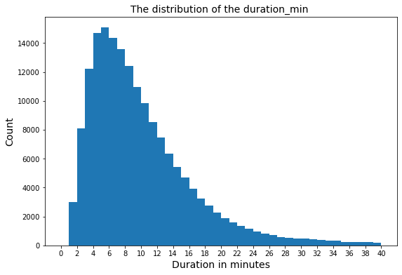

## (Number of trips per day)

> As we see in the chart, most of the trips happened in the work days more than the vacations, so most of the people's trip were for work.

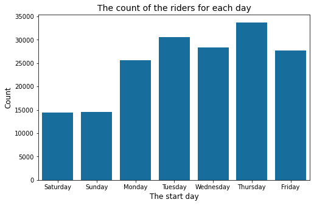

## (Number of trips per hour)

> to make sure of the conclusion I made about people's trip are for work, this chart is showing the hours that has the most trips, and it was 8am and 5pm, and this confirms my previous conclusion.

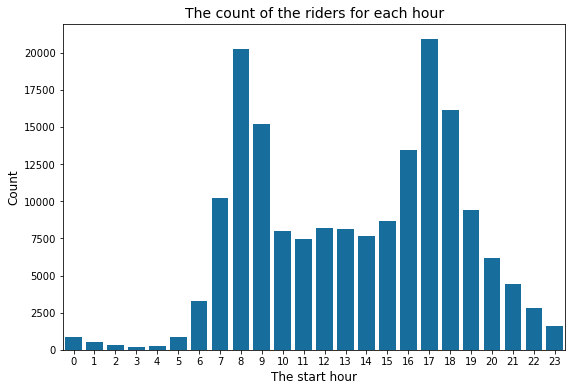

## (Number of each user type)

> I studied the numbers of each user type, whether a customer or a sbuscriber, and the chart shows that the subscribers are more than customers.

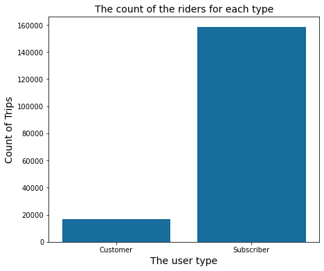

## (The relation between the Age and the Duration per minute)

> I studied the relation between the user's age and the trip duration, and found that the people from the age of 20 to the age of 40 took trips lasting from two minutes to 40 minutes.

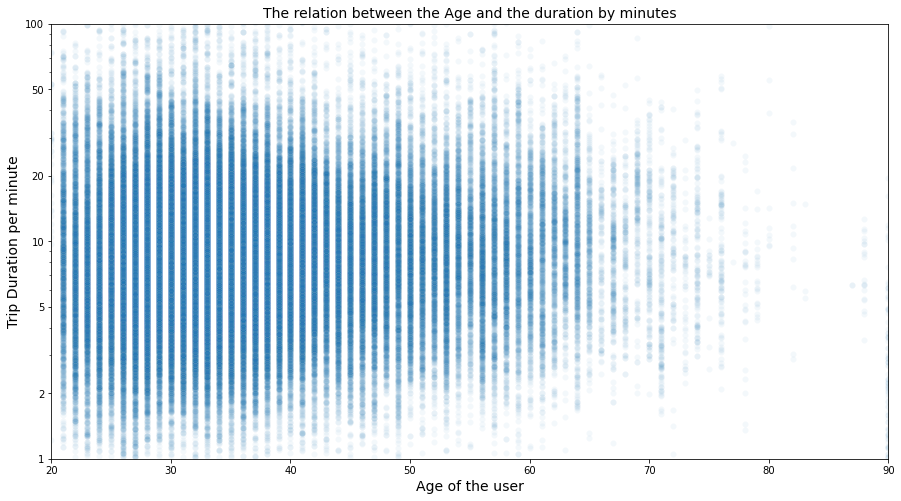

## (The relation between the Age and the Duration per minute per user type)

> Now I looked at the relation between the Age of the user and the trip duration per user type, to find that the trip duration doesn't differ from customer to subscriber, as for both types the duration decreases when the age increases. But to see the difference, I seperated each type to its chart, and found that the age of the subscribers is more than the age of the customers.

> The final result I got is that the Ford GoBike System has managed to attract large number of customers to subscribe, and to keep using the system for a long time, and it managed to attrack large scale of ages (from 20 to more than 90 years old)

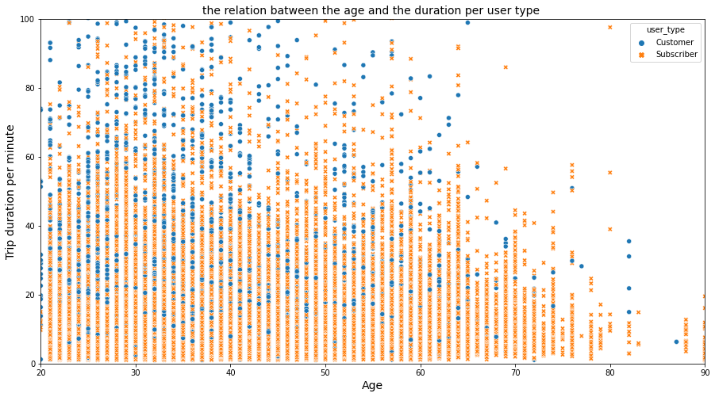

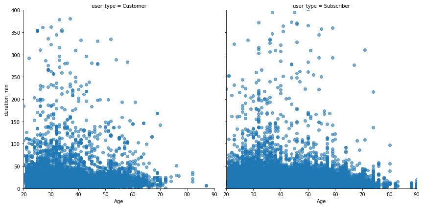